# Practice Chapter 3 SR

Pablo Bello

9/23/2022

```r
library(rethinking)
library(ggpubr)
```

```r
###--- Setup
p_grid <-seq(from=0,to=1,length.out=1000)
prior <-rep(1,1000)
likelihood <-dbinom(6,size=9,prob=p_grid)
posterior <-likelihood*prior
posterior <-posterior/sum(posterior)
set.seed(100)
samples <-sample(p_grid,prob=posterior,size=1e4,replace=TRUE)
```

### 3E1. How much posterior probability lies below p = 0.2?

```r
sum(samples < .2)/1e4
```

```
## [1] 4e-04
```

### 3E2. How much posterior probability lies above p = 0.8?

```r
sum(samples > .8)/1e4
```

```
## [1] 0.1116
```

### 3E3. How much posterior probability lies between p = 0.2 and p = 0.8?

```r
sum(samples > .2 & samples < .8)/1e4
```

```
## [1] 0.888
```

### 3E4. 20% of the posterior probability lies below which value of p?

```r
quantile(samples, .2)
```

```
##       20%
## 0.5185185
```

### 3E5. 20% ofthe posterior probability lies above which value of p?

```r
quantile(samples, .8)
```

```
##       80%
## 0.7557558
```

### 3E6. Which values of p contain the narrowest interval equal to 66% of the posterior probability?

```r
HPDI(samples , prob = .66)
```

```
##     |0.66     0.66|
## 0.5085085 0.7737738
```

### 3E7. Which values of p contain 66% of the posterior probability, assuming equal posterior probability both below and above the interval?

```r
###--- The hard way

quantile(samples, ((1 - .66)/2)) # lower bound
```

```
##       17%
## 0.5025025
```

```r
quantile(samples, ((1 - .66)/2 + .66)) # upper bound
```

```
##       83%
## 0.7697698
```

```r
###--- Or the easy way
PI(samples, prob = .66)
```

```
##       17%       83%
## 0.5025025 0.7697698
```

### 3M1

```r
###--- Load my function (same as in ch2 script)
source("week_4/helper_functions.R")

###--- Compute grid approximation for W = 8, L = 7 and a flat prior
tbl <- grid_approx(W = 8, L = 15 - 8,grid_n = 1000,plot = FALSE)

head(tbl)
```

```
## # A tibble: 6 × 2
##   p_water posterior_probability
##     <dbl>                 <dbl>
## 1 0                    0
## 2 0.00100              1.03e-22
## 3 0.00200              2.62e-20
## 4 0.00300              6.67e-19
## 5 0.00400              6.62e-18
## 6 0.00501              3.92e-17
```

### 3M2

```r
samples <- sample(tbl$p_water, prob = tbl$posterior_probability, size = 1e4, replace = TRUE)

HPDI(samples, .9)
```

```
##      |0.9      0.9|
## 0.3293293 0.7167167
```

### 3M3

```r
w <- rbinom(1e4, size = 15, prob = samples) # Some predictions
sum(w == 8)/1e4 # P of 8 waters in 15 tosses
```

```
## [1] 0.1444
```

### 3M4

```r
w <- rbinom(1e4, size = 9, prob = samples) # Some predictions
sum(w == 6)/1e4 # P of 6 waters in 9 tosses
```

```
## [1] 0.1751
```

### 3M5

```r
###--- Use the step prior now
tbl2 <- grid_approx(W = 8, L = 15 - 8, grid_n = 1000, plot = FALSE, prior_f = "step")
samples2 <- sample(tbl2$p_water, prob = tbl2$posterior_probability, size = 1e4, replace = TRUE)

HPDI(samples2, .9)
```

```
##      |0.9      0.9|
## 0.5005005 0.7117117
```

**With the new priors the 90% HPDI is narrower.**

```r
w2 <- rbinom(1e4, size = 15, prob = samples2) # Some predictions
sum(w2 == 8)/1e4 # P of 8 waters in 15 tosses
```

```
## [1] 0.1589
```

**The probability of 8 water in 15 tosses is slightly higher (from ~.15 to ~.16).**

```r
w2 <- rbinom(1e4, size = 9, prob = samples2) # Some predictions
sum(w2 == 6)/1e4 # P of 8 waters in 15 tosses
```

```
## [1] 0.2415
```

**And the probability of 6 water in 9 tosses is higher as well (from ~.17 to ~.24). Which makes sense when we consider that the new priors favor higher P of water.**

### 3M6

**Can’t be done. There is not enough atoms in the universe.**

### 3H1

```r
data(homeworkch3)

###--- Number of boys
b <- sum(birth1) + sum(birth2)
l <- length(birth1) + length(birth2)
tbl <- grid_approx(W = b,L = l - b,grid_n = 1e4,plot = FALSE)

tbl |>
  filter(posterior_probability == max(posterior_probability)) |>
  rename(p_boy = p_water)
```

```
## # A tibble: 1 × 2
##   p_boy posterior_probability
##   <dbl>                 <dbl>
## 1 0.555               0.00114
```

**0.555 is the value for p_boy that maximizes the posterior probability.**

### 3H2

```r
###--- Sample from posterior
samples <- sample(tbl$p_water, prob = tbl$posterior_probability, size = 1e4, replace = TRUE)

###-- 50%, 89% and 97% posterior density interval
HPDI(samples, .5)
```

```
##      |0.5      0.5|
## 0.5316532 0.5771577
```

```r
HPDI(samples, .89)
```

```
##     |0.89     0.89|
## 0.4993499 0.6102610
```

```r
HPDI(samples, .97)
```

```
##     |0.97     0.97|
## 0.4793479 0.6301630
```

### 3H3

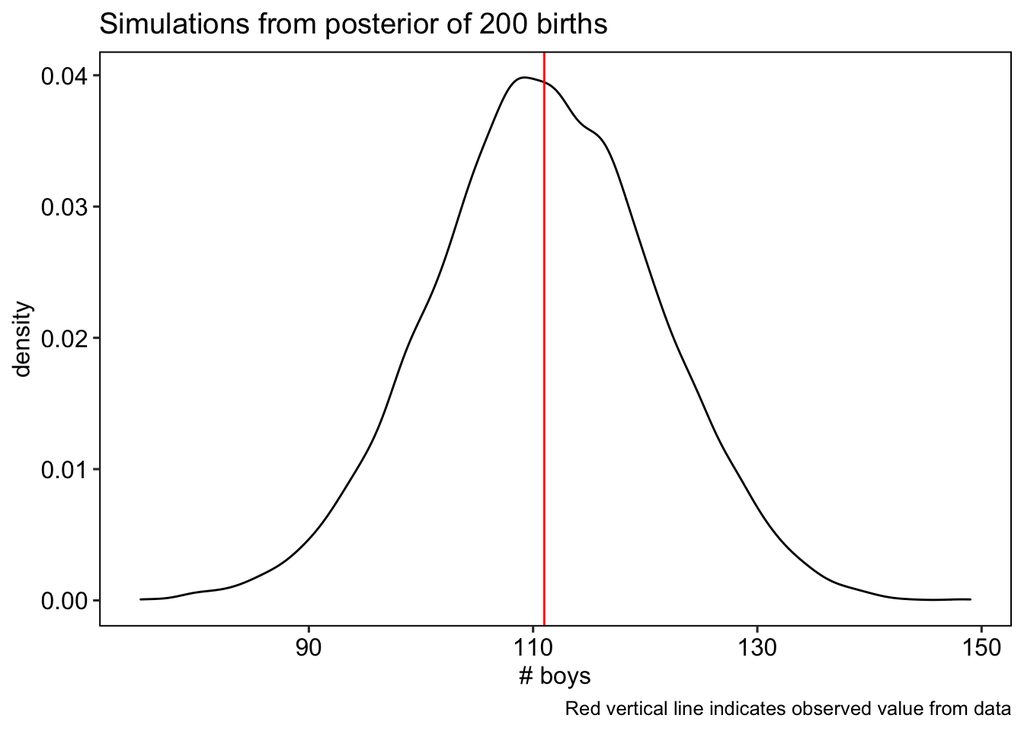

```r
w <- rbinom(1e4, size = 200, prob = samples) # Some predictions

tibble(w) |>
  ggplot(aes(w)) +
  geom_density() +
  theme_pubr(border = TRUE) +
  labs(x = "# boys",
       title = "Simulations from posterior of 200 births",
       caption = "Red vertical line indicates observed value from data") +
  geom_vline(aes(xintercept = b), color = "red")
```

**The model seems to fit well. The observed number of male births is the peak or near the peak of the distribution.**

### 3H4

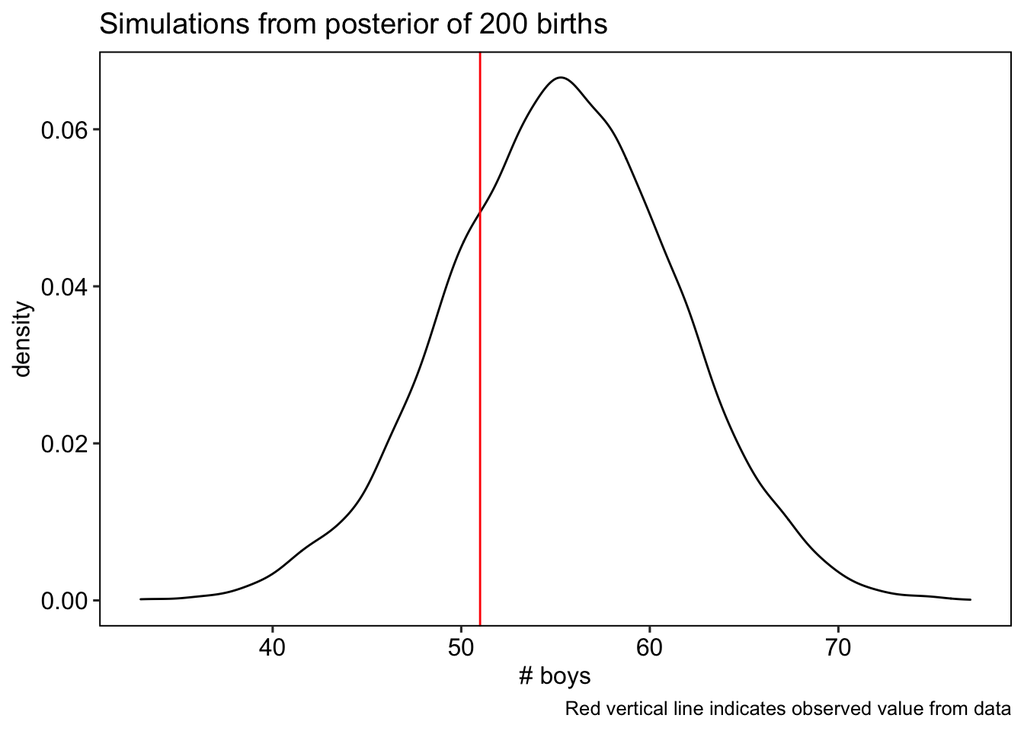

```r
w <- rbinom(1e4, size = 100, prob = samples) # Some predictions

tibble(w) |>
  ggplot(aes(w)) +
  geom_density() +
  theme_pubr(border = TRUE) +
  labs(x = "# boys",
       title = "Simulations from posterior of 200 births",
       caption = "Red vertical line indicates observed value from data") +
  geom_vline(aes(xintercept = sum(birth1)), color = "red")
```

**The model is not as good as before. The distribution of predicted number of boys out of 100 births is not centered around the observed value.**

### 3H5

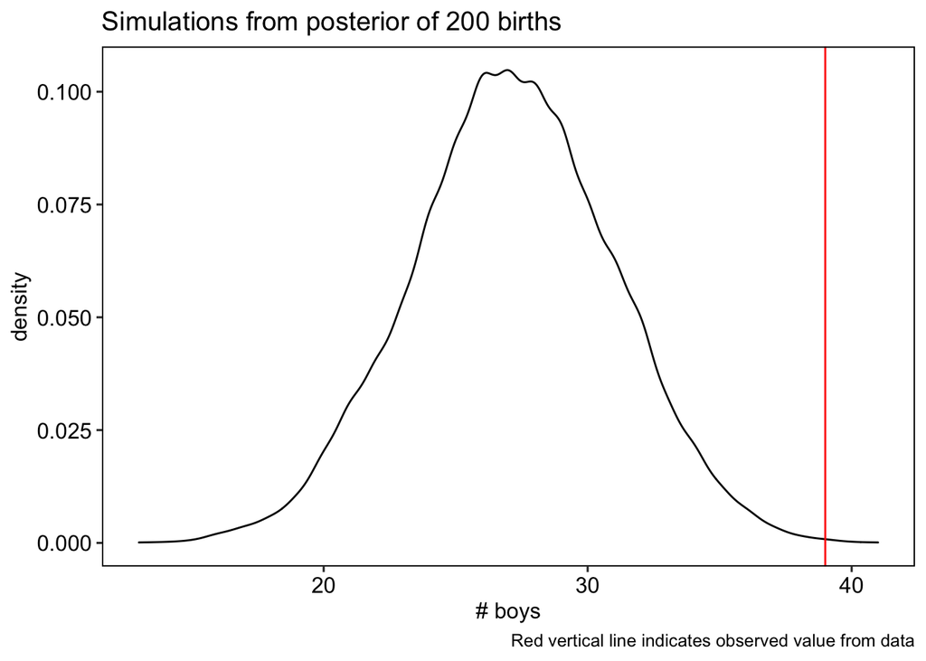

```r
girls <- which(birth1 == 0)
n_girls <- length(girls)
boys_2 <- sum(birth2[girls] == 1)


w <- rbinom(1e4, size = n_girls, prob = samples) # Some predictions

tibble(w) |>
  ggplot(aes(w)) +
  geom_density() +
  theme_pubr(border = TRUE) +
  labs(x = "# boys",
       title = "Simulations from posterior of 200 births",
       caption = "Red vertical line indicates observed value from data") +
  geom_vline(aes(xintercept = boys_2), color = "red")
```

**Even worse fit than before. The model is making predictions that look nothing like the data. So we can guess that the births are not independent. There is a negative correlation between the sex at first birth and second birth. Boys tend to follow girls and girls follow boys. Although in real data the correlation seems to be positive.**